# Raport z wykresowych eksperymentów

Natalia Safiejko i Zuzanna Piróg

2022-11-19

## Czy problemy z odczytywaniem danych z wykresów dalej występują?

Zadanie polegało na tym by sprawdzić czy wśród społeczeństwa wciąż występują omawiane na zajęciach problemy z odczytywaniem danych z wykresów Aby to zbadać przeprowadziłyśmy dwa eksperymenty.

Nasze badanie przeprowadziłyśmy przy pomocy platformy Google Forms i otrzymałyśmy 26 odpowiedzi:  
Link:  
https://forms.gle/8zxvNdJGBB476Pdt5

### Pierwszy eksperyment

W pierwszym eksperymencie postanowiłyśmy zbadać czy niepoprawna skala i kolory na wykresie mają znaczenie.

Wykres nr 1 to wykres, którego skala y nie zaczyna się od 0, tylko od konkretnej wartości, przez co wykres także inaczej wygląda:

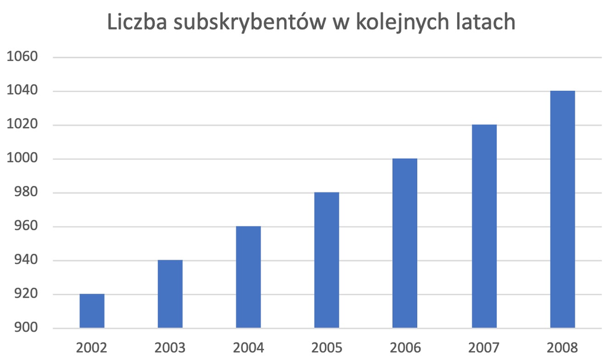

Może on sugerować, że wartość liczby subkrybentów wzrastała dużo szybciej niż w rzeczywistości

Dla porównania: wykres nr 2 z poprawną skalą y- zaczynającą się od 0

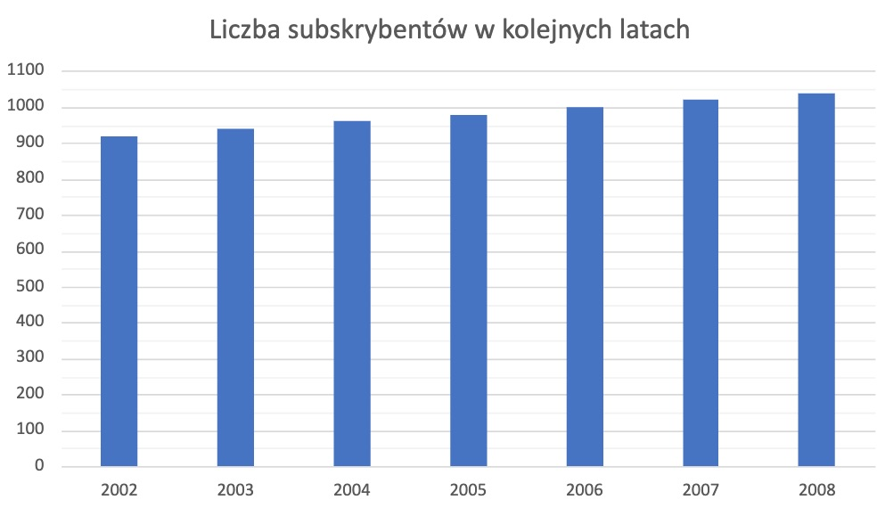

## Wyniki pierwszego eksperymentu

### Pytanie nr 1

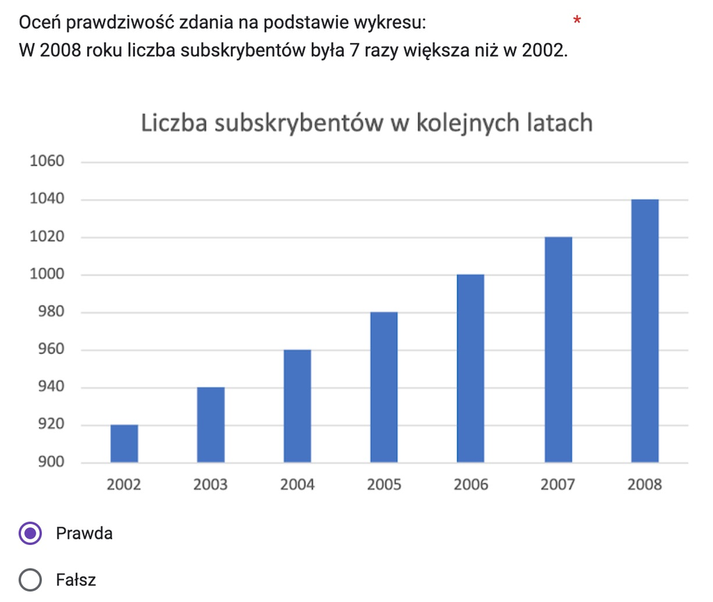

#### Wyniki:

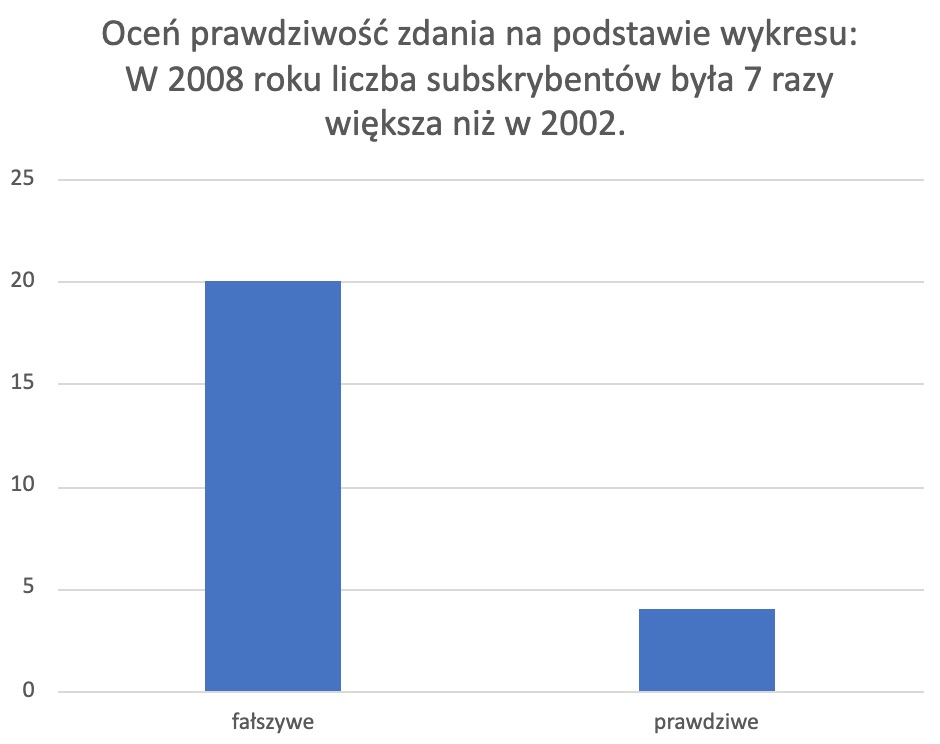

Jak widać, większość ankietowanych odpowiedziała poprawnie na pytanie, jednak znalazły się też osoby, które dały się zmanipulować.

### Pytanie nr 2

Na wykresie dodatkowo jeden rok został zaznaczony innym kolorem. Czy wpłynęło to na odczytanie danych z wykresu?

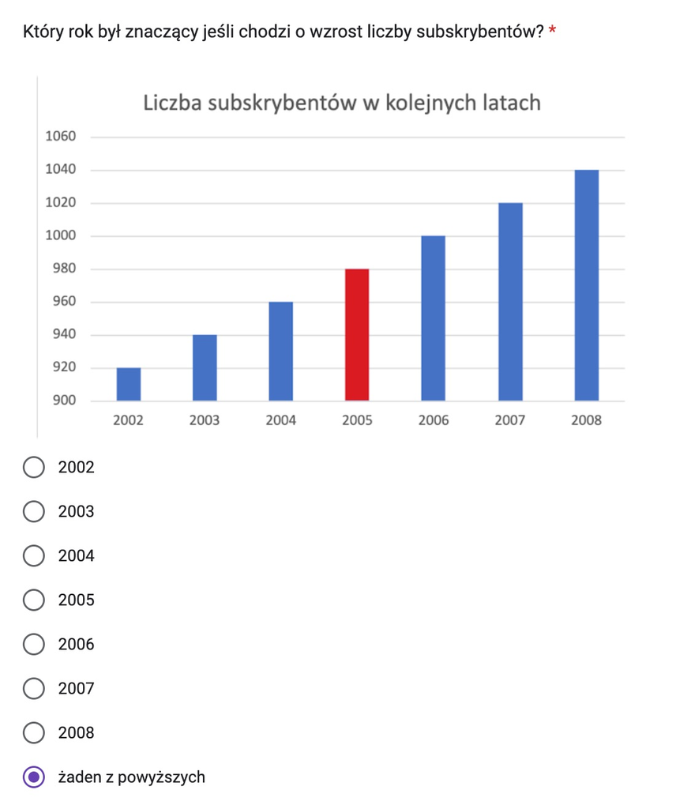

#### Wyniki:

[figure not shown]

Większość osób odpowiedziała poprawnie na pytanie, jednak część z nich zwróciła uwagę na wyróżniony rok, mimo że w porównaniu z innymi nie różnił się wzrostem wartości.

### Pytanie nr 3 i 4

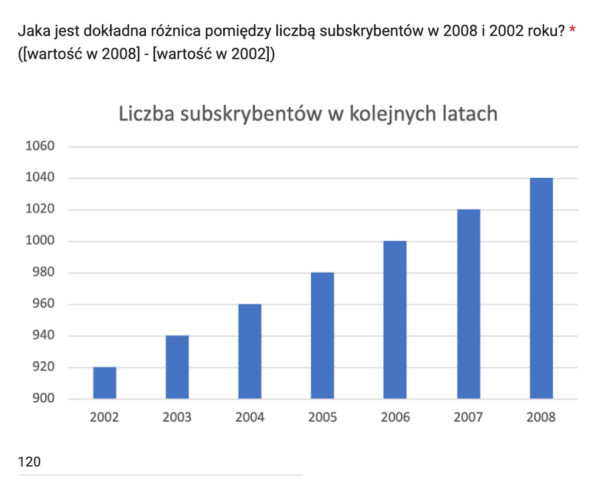

To pytanie miało na celu zwrócenie uwagi, że mimo iż patrząc na wykres może wydawać się, że wartość pomiędzy 2008 i 2002 rokiem znacząco sie różni, w rzeczywistości różnica wynosi tylko 120. Wszystkie udzielone odpowiedzi były poprawne.

Powiązane jest to z pytaniem 4:

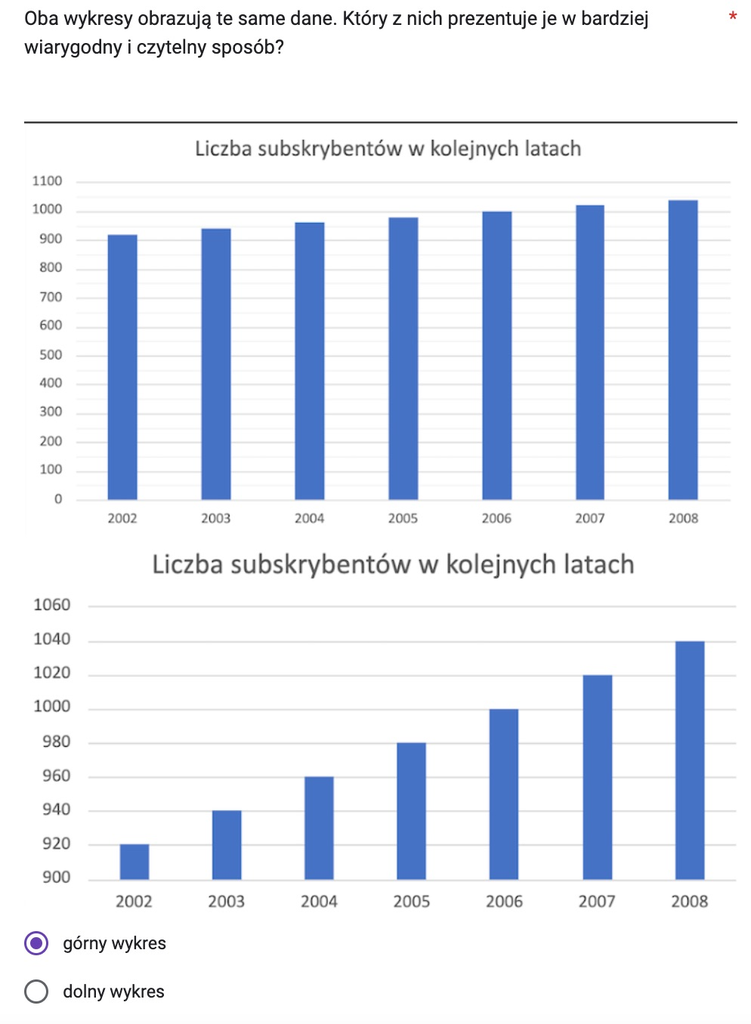

#### Wyniki:

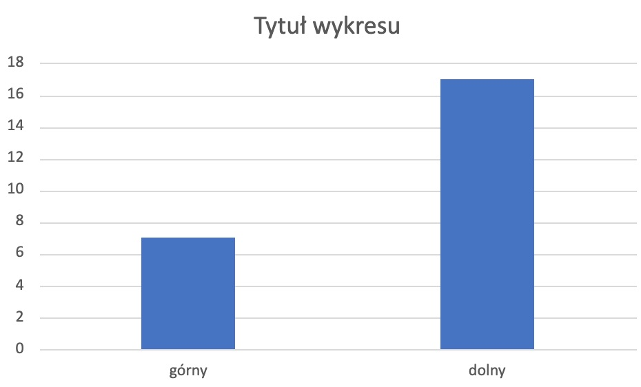

Większość osób wybrała wykres z niepoprawną skalą y. Powodem mogła być dokładniejsza skala, która ułatwia odczytywanie danych. Jednak biorąc pod uwage przedstawienie danych w wiarygodny sposób to lepszy jest wykres górny. który pokazuje, że wzrost wartości w kolejnych latach nie jest aż tak duży jak mogłoby się wydawać.

## Podsumowanie pierwszego eksperymentu

Z wyników eksperymentu można wywnioskować, że wykresy z niepoprawną osią Y i z wyróżnionymi fragmentami dalej mogą manipulować odczytującymi dane.

# Drugi eksperyment

Drugi eksperyment miał na celu zbadanie, czy łatwiej odczytuje się dane z wykresów trójwymiarowych w porównaniu do wykresów dwuwymiarowych. Ponadto w jedym z wykresów 3D uwzględniłyśmy wykres kołowy który teoretycznie już w formie 2D może być trudny do odczytu. Wszystkie wykresy zostały stworzone na podstawie jednej ramki danych, reprezentującej ilość wypadków spowodowaną przez daną płeć w poszczególnych miesiącach.

Poniżej omawiana ramka danych:

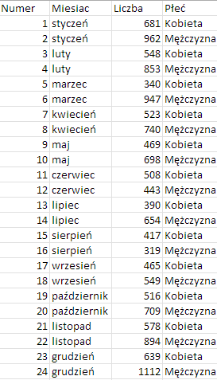

Eksperyment polegał na zbadaniu sprawności ankietowanych w odczytywaniu danych z wykresu 3D. Najpierw ankietowani zostaną poproszeni o udzielenie poprawnych odpowiedzi na podstawie wykresów, które są trudne do oczytania i mają wiele nieporządanych cech. W dalszej części eksperymentu ankietowani będą ponownie odpowiadać na te same pytania, tym razem korzystając z dobrego wykresu. Ma to na celu sprawdzić, czy odczyt danych zostanie ułatwione i czy poprawność odpowiedzi wzrośnie.

Pierwszy zaproponowany wykres 3D:

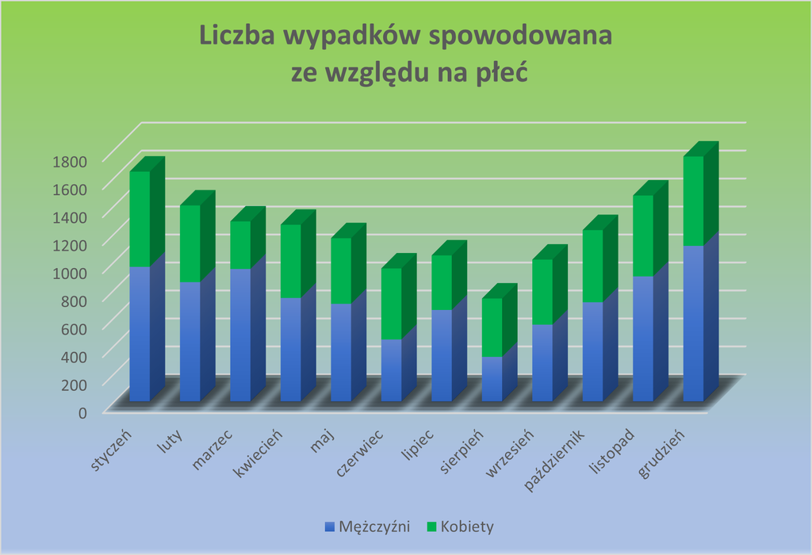

Wykres ten naszym zdaniem jest wyjątkowo ciężki do odczytu. Wpływają na to m.in.:

- Cienie poniżej kolumn (nie wiadomo gdzie tak naprawdę zaczyna się słupek),
- Oznaczenia na osi Y wysunięte do przodu w porównaniu do tła wykresu,
- Oznaczenia na osi X, umieszczone pod kątem i w zdaje się większej odległości od słupków (trzeba dopasować nazwę do słupka),
- Dane “zestakowane” w jeden słupek (miało to zmusić ankietowanych do wykorzystania osi Y do odczytu danych), nie wiadomo kiedy kończy się jedna dana, brak możliwości szybkiego porównania,
- Musimy się zastanowić nad perspektywą i uwzględnić ją przy odpowiedziach na pytania.

Poprawny wykres:

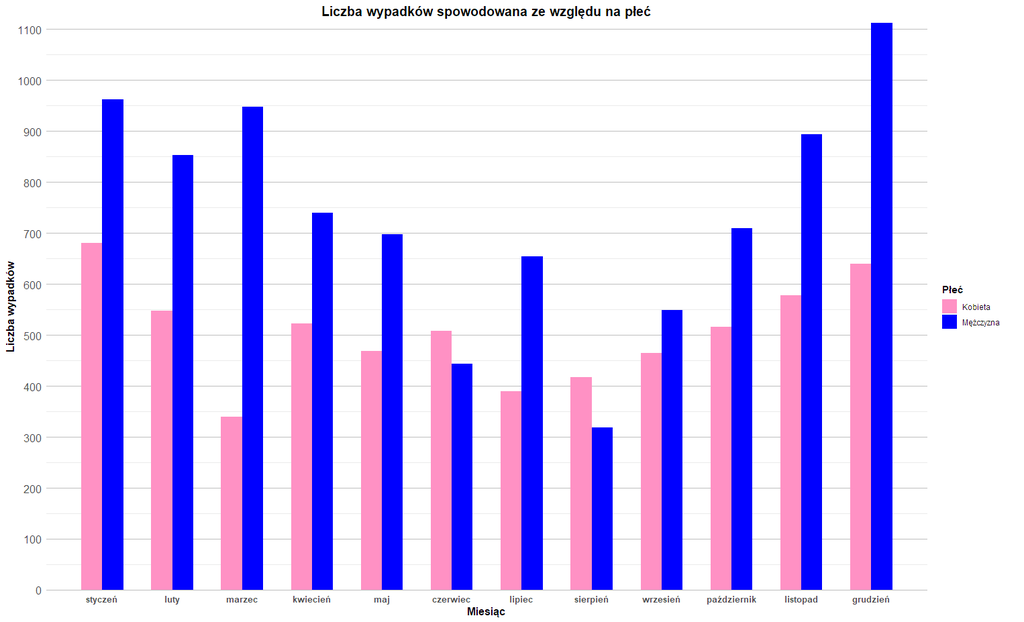

Wykres jest łatwy w odczycie, ponieważ:

- Oznaczenia na osi OY pokrywają się z liniami tła wykresu,
- Oznaczenia na osi OX są wyraźne i dopasowane bezpośrednio pod słupkami danych, których dotyczą,
- Brak rozpraszających cieni, które utrudniałyby odczyt,
- Słupki kobiet i mężczyzn znajdują się obok siebie, łatwiej jest odczytać stosunki między nimi,
- Łatwo odnaleźć najwyższy i naniższy słupek wśród męczyzn i kobiet.

Drugi wykres 3D tym razem w wersji kołowej:

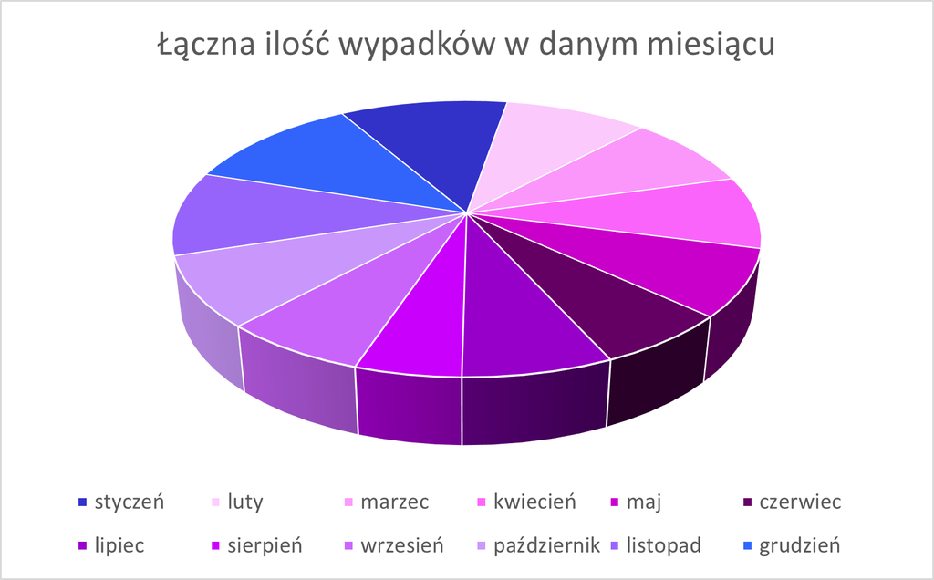

Oprócz wymienionych już wcześniej problemów dla wykresu słupkowego 3D, powyższy wykres jest trudny w odczycie, ponieważ:

- Kolory nie są wystarczająco rozróżnialne,
- Nie można odczytać faktycznych wartości, widzimy tylko ich udział,
- Mamy utrudnienie w odczytywaniu proporcji spowodowane perspektywą,
- Kolory nie są wystarczająco rozróżnialne,
- Te obszary, które wydają się być największe zostały umieszczone w tylnej części wykresu, nie mamy ich jak porównać,
- Aby odczytać coś z wykresu najpierw musimy zlokalizować kolor, a dopiero później szukać jego odpowiednika w legendzie.

Poprawny wykres:

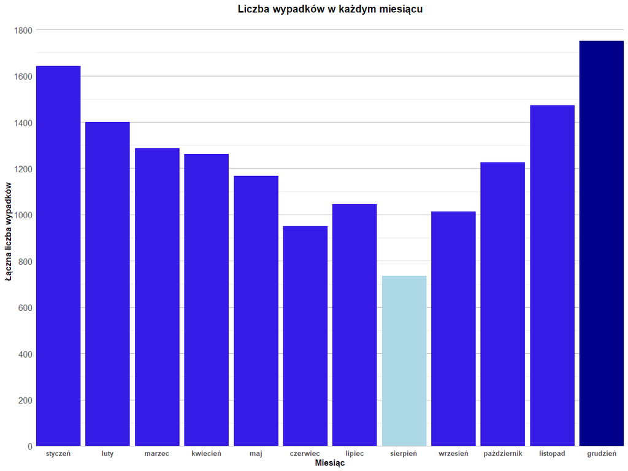

Wykres jest łatwy w odczycie, ponieważ:

- Wszystkie słupki umieszczone są obok siebie, w odpowiedniej kolejności, łatwo odnaleźć interesujący nas miesiąc
- Mamy jednakową perspektywę,
- Opisy kolumn znajdują się bezpośrednio pod nimi,
- Najwyższy i najniższy słupek wyróżniony kolorami, oprócz nich reszta słupków jest jednolita, co ułatwia ich porównywanie.

## Wyniki drugiego eksperymentu

### Pytanie 5

Pytanie miało sprawdzić czy ankietowani są w stanie szybki i bezproblemowy sposób jednoznacznie wyznaczyć najwyższy słupek wśród kobiet.

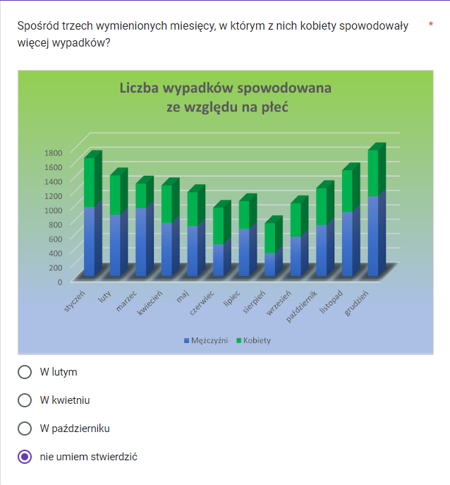

#### Wyniki

Jak widać na poniższym wykresie większość ankietowanych nie umiała odpowiedzieć na to pytanie. Opcja “nie umiem stwierdzić” miała na celu uniknięcie zgadywania odpowiedzi, znaczna większość osób wybrała właśnie ją.

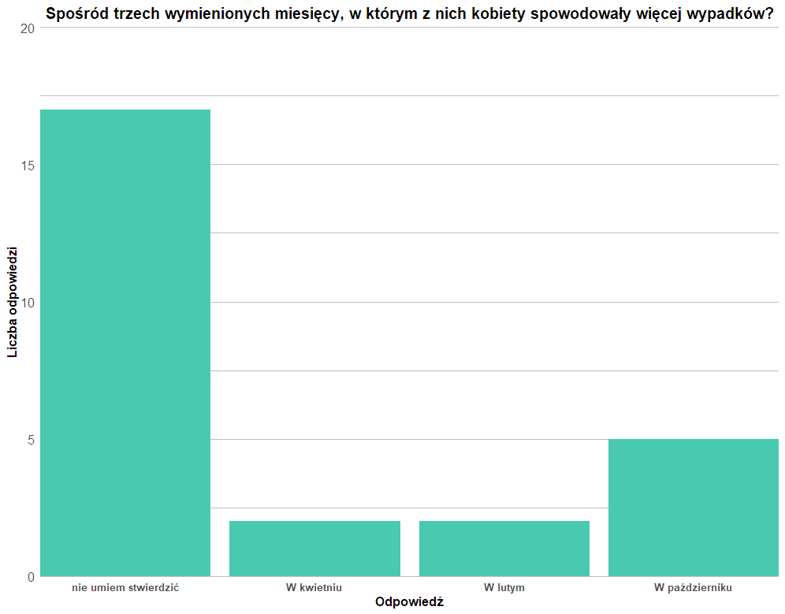

### Pytanie 6

Tym razem ankietowanym został przedstawiony poprawny wykres, należało ponownie odpowiedzieć na wcześniej postawione pytanie.

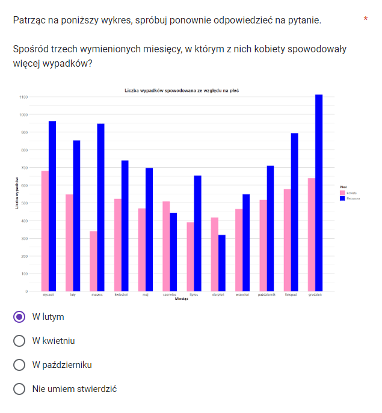

#### Wyniki

Tym razem praktycznie wszyscy ankietowani udzielili poprawnej odpowiedzi, tylko pojedyńcze jednostki źle odczytały dane.

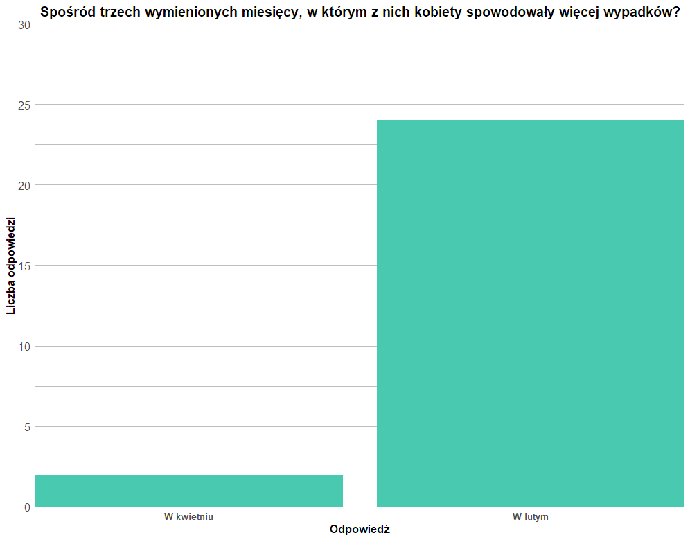

### Pytanie 7

W tym pytaniu sprawdzana była umiejętność odczytu danych z osi Y. Wyniki okazały się zaskakujące

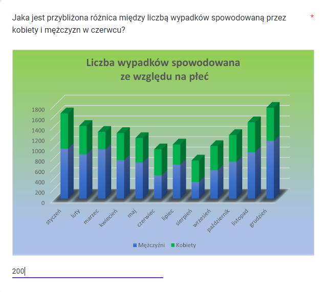

#### Wyniki

Prawie wszyscy ankietowani błędnie odpowiedzieli. Prawidłowa odpowiedź to +- 60, jednak pomyłka odpytywanych była rzędu setek a nie dziesiątek.

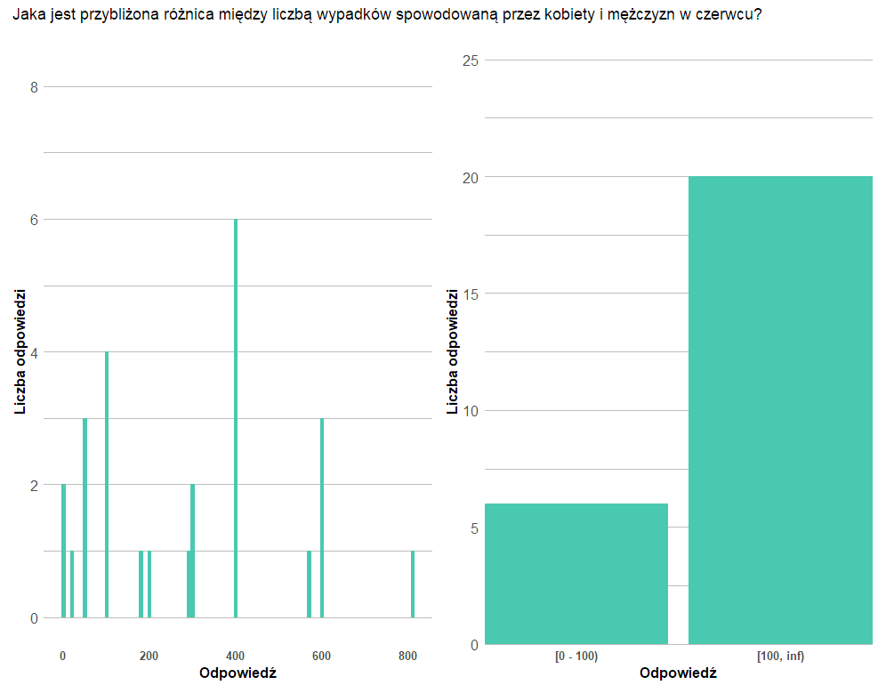

### Pytanie 8

Ponownie użytkownicy musieli odpowiedzieć na pytanie bazując tym razem na poprawnym wykresie.

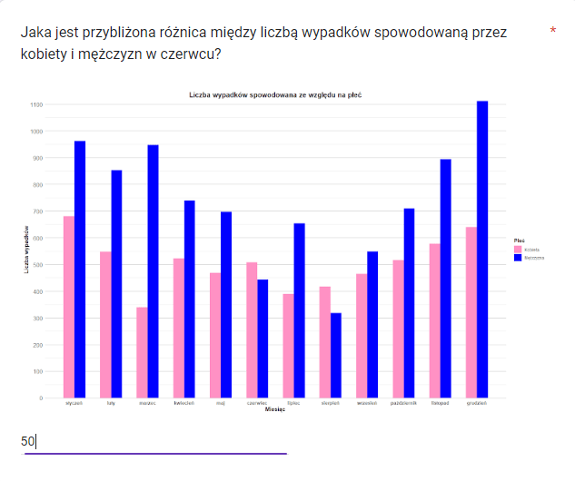

#### Wyniki

Tym razem prawie wszyscy ankietowani wskazali prawidłową odpowiedź.

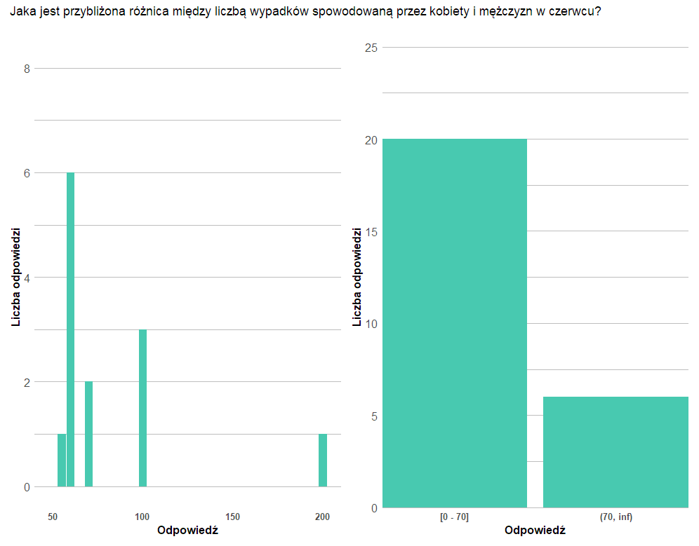

### Pytanie 9

Ankietowani mieli wybrać wykres łatwiejszy do odczytu.

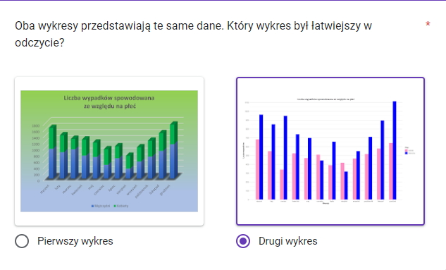

#### Wyniki

Uzyskany rezultat jasno wskazuje, że wygrał wykres dwuwymiarowy.

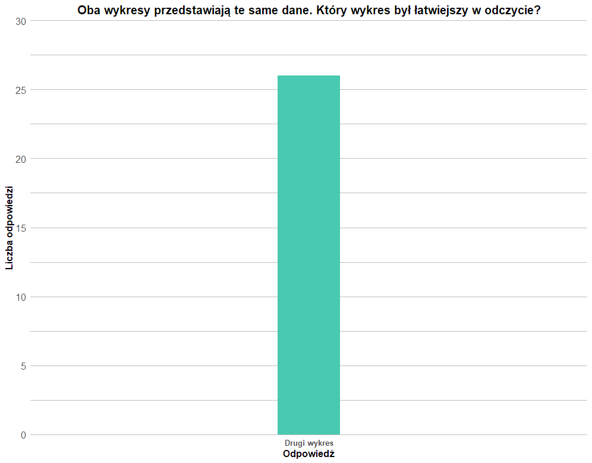

### Pytanie 10

W tym pytaniu sprawdziłyśmy jak sprawdzi się trójwymiarowy wykres kołowy.

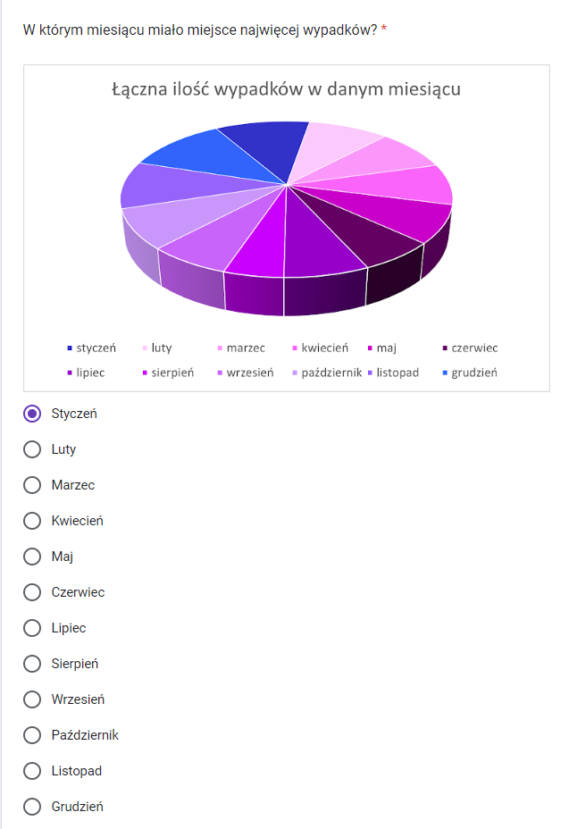

#### Wyniki

Prawidłową odpowiedzią jest grudzień. Ponownie większość ankietowanych wskazała na błędną odpowiedź i źle odczytała proporcje wskazując styczeń.

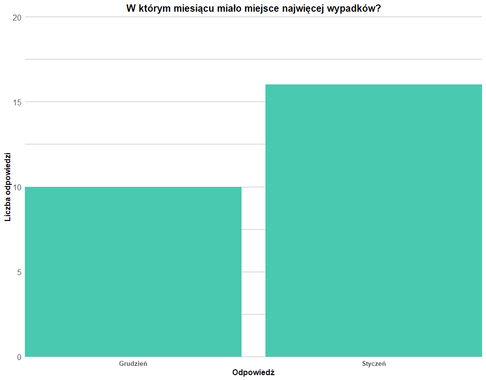

### Pytanie 11

Tym razem użytkownicy mieli odczytać wykres słupkowy i ponownie odpowiedzieć na to samo pytanie

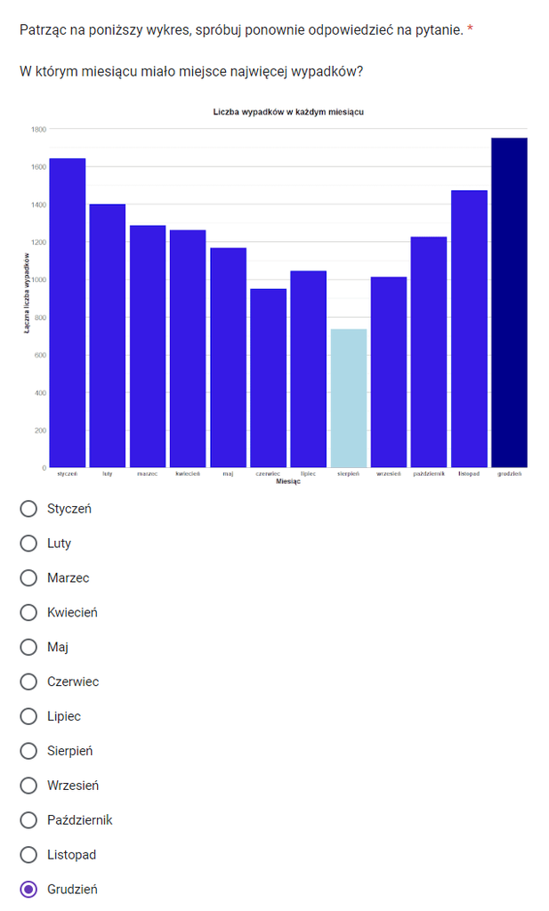

#### Wyniki

Ankietowani byli jednogłośni i wszyscy poprawnie odpowiedzieli na postawnione pytanie.

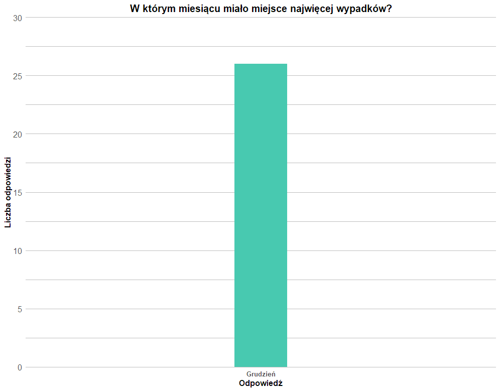